# Introduction to Satistical Computing and Computational Statistics

Brad Price, Ph.D.

## Introduction to Statistical Computing and Computational Statistics

Traditional statistics courses focus on formulas and p-values that come from a table or straight out of the back of a textbook, while I believe that has it’s place in analytics we need to focus more on understanding the principals behind these methods, so that we can help decision makers understand what their data is telling them. To do this we use computational tools, software and HPC systems. This module focuses on Statistical Computing, specifically R though we will touch on SAS and you will have access to SAS University (free software and trainings). Both softwares have their place in the field, one of the reasons we use R is the price point (it’s free) and SAS outside of universities is not. SAS is used at many large firms, while R can be downloaded anywhere and used anywhere. Exposure to both is a great thing, though R has a stronger usage and place in the field of data science.

Through out this module we will discuss R as a software, data structures, and how to randomly generate data and sample information to discuss bootstrap and randomization testing, to better understand statistical inference techniques. We will introduce some basic R concepts and data structures, random number generation, and then getting into combining this to create statistical inference.

## Introduction to R

### What is R?

R is a free statistical software that is used by both applied and research statisticians. If this were a statistics course for future statisticians that would be enough, but it’s not. So why are we using R in a business statistics class? Because over the past few years people in industry, start-ups, government, medicine, and consulting have realized what those in statistics realized over a decade ago; R one of the most powerful tools we have to analyze data. There are many other tools that have similar capabilities to R but the major advantage of R is that it is ** FREE **. It is free as in no cost, and free as in you can do whatever you want with it. It is designed to do things as simple as calculating means and as complex as recommending songs on systems like Pandora. The last reason we are using it is because it is the ``it” thing in statistics and analytics right now. If you can use R you can use and learn any other statistical software easily. One of the things you will be able to take away from this course at the end is a line on your resume that you have experience in R.

Now we need to understand this class isn’t going to be all about computing, but will be about how to use computing to answer questions of interest. Statistical software makes our life easier and allows us to focus more on how to apply results to our question, than about equations and actually doing the calculations by hand. Here we are going to use it to understand the 3 basic concepts of intro statistics

- Central Limit Theorems
- Hypothesis Testing
- Confidence Intervals

### Using R

The next thing that we need to understand about R is that it is only as smart as the user, which means it will only do what you tell it to do. If you don’t let R know what to do then it can’t do it. The best way I think we can learn R is do review what you should know from previous courses and use R to do it.

### Dealing with Data in R

Sometimes the hardest part of an analysis is simply getting the data in the correct format to analyze. R functions really well with many different data types, but one of the easiest to deal with is .csv files. The reason we like .csv files so much is that we can save any Excel file as a .csv, all you need to do is change the file type (File> Save as> Save as type then select .csv). Before doing this make sure all formatting is removed. R doesn’t care if something is in dollars a color coding you have on a spreadsheet, it just wants the numbers or words you have the in file that is all.

Something else to remember in R we always want our data to be in ``matrix” form. That is when it is in the excel file the rows should be our observations and the columns should be the variables of interest for those observations. Sometimes people call this a long form of the data, for visualizing it is not the best thing, but for analysis it is **The. Right. Thing.** (TRT).

For now we will use a data set that is already in an **R Package**. R is developed by researches all over the world if you want the latest and greatest techniques to use on your data there is more than likely an R package that will do it for you. A lot of the time to give examples they will include data sets (which is what we will be using in this case). Now to get things started we need to install the package. You need to be connected to the internet.  
To do this we type

```r
install.packages("alr4")
library(alr4)
```

Now this looks very complicated but it isn’t once we understand that R is built with functions so if we can understand the functions we understand exactly what R is doing. Let’s take a look at the command

```r
install.packages("alr4")
```

We call

- `install.packages` the function (the thing before the parentheses)
- `alr4` is the object is the object (anything inside the parentheses).

Think of this as we want to install the package alr4. Sometimes after you run a code like this especially if you are in a new R session it will ask you to select a new mirror (just select something in the US).

Now that we have it installed we need to tell R to load the package. The `library` function does this. It tells the software that I have downloaded a package and I want to use what it is in it. In this case the function is `library` and the object is `alr4`. Notice also that `alr4` is not in quotation marks, that is because since it is downloaded R already recognizes it as something you’ve downloaded.

The next thing we are going to do is look at a data set that looks at specific economic factors in different major cities from a 2003 Union Bank of Switzerland Report. It looks at the number of minuets of labor that goes into purchasing 1 kg of rice, 1 kg of bread, and 1 Big Mac in each of these cities. Other economic factors are also included. To look at a sample of the data we will use the `head` function on the data set which is named `BigMac2003`.

```r
library(alr4)
data(BigMac2003)
head(BigMac2003)
```

```
##           BigMac Bread Rice FoodIndex  Bus Apt TeachGI TeachNI TaxRate
## Amsterdam     16     9    9      65.9 2.00 890    34.3    20.5 40.2332
## Athens        21    12   19      63.5 0.61 620    19.5    15.9 18.4615
## Auckland      19    19    9      55.4 1.57 780    22.0    16.1 26.8182
## Bangkok       50    42   25      46.4 0.47 120     4.2     4.0  4.7619
## Barcelona     22    19   10      62.9 0.91 590    25.5    20.1 21.1765
## Basel         15     7    7      98.4 2.34 930    78.5    57.6 26.6242
##           TeachHours
## Amsterdam         39
## Athens            29
## Auckland          40
## Bangkok           35
## Barcelona         39
## Basel             35
```

We see want to know how big the data set actually is to do this we check the dimension of the data set. To do this use the function

```r
dim(BigMac2003)
```

```
## [1] 69 10
```

We have 69 rows (cities) and 10 columns (variables).

The `attach` function says take my data set and let me call the variable by their names. This means we can show that

```r
attach(BigMac2003)
BigMac
```

```
##  [1]  16  21  19  50  22  15  16  93  54  18  79  43  45  76  10  16  22  15  15
## [20]  16  19  13  36  67  33 132  84  25  55  79  33  39  16  10  17  15  21  24
## [39]  62  75  10  21  14  30 112 185  12  18  19  42  48  43  26  52  33  28  30
## [58]  21  31  19  19  18  49  31  10  14  15  62  44
```

```r
BigMac2003$BigMac
```

```
##  [1]  16  21  19  50  22  15  16  93  54  18  79  43  45  76  10  16  22  15  15
## [20]  16  19  13  36  67  33 132  84  25  55  79  33  39  16  10  17  15  21  24
## [39]  62  75  10  21  14  30 112 185  12  18  19  42  48  43  26  52  33  28  30
## [58]  21  31  19  19  18  49  31  10  14  15  62  44
```

are the exact same. This keeps us from having to write an excessive amount of code, and lets us call the variables by their name rather than by their data set and name.

This is great but what if we wanted to know what all the cities we had in our data set without looking at the entire data set. To do this we use the function `rownames`.

```r
rownames(BigMac2003)
```

```
##  [1] "Amsterdam"         "Athens"            "Auckland"
##  [4] "Bangkok"           "Barcelona"         "Basel"
##  [7] "Berlin"            "Bogota"            "Bratislava"
## [10] "Brussels"          "Bucharest"         "Budapest"
## [13] "Buenos_Aries"      "Caracas"           "Chicago"
## [16] "Copenhagen"        "Dubai"             "Dublin"
## [19] "Frankfurt"         "Geneva"            "Helsinki"
## [22] "Hong_Kong"         "Istanbul"          "Jakarta"
## [25] "Johannesburg"      "Karachi"           "Kiev"
## [28] "Kuala_Lumpur"      "Lagos"             "Lima"
## [31] "Lisbon"            "Ljubljana"         "London"
## [34] "Los_Angeles"       "Lugano"            "Luxembourg"
## [37] "Madrid"            "Manama"            "Manila"
## [40] "Mexico_City"       "Miami"             "Milan"
## [43] "Montreal"          "Moscow"            "Mumbai"
## [46] "Nairobi"           "New_York"          "Oslo"
## [49] "Paris"             "Prague"            "Riga"
## [52] "Rio_De_Janeiro"    "Rome"              "Santiago_De_Chile"
## [55] "Sao_Paulo"         "Seoul"             "Shanghi"
## [58] "Singapore"         "Sofia"             "Stockholm"
## [61] "Sydney"            "Taipei"            "Tallinn"
## [64] "Tel_Aviv"          "Tokyo"             "Toronto"
## [67] "Vienna"            "Vilnius"           "Warsaw"
```

So we see that Miami is in our data and is observation number 41 how do we look specifically at Miami without looking at everything else. Well if we think of our data as having rows and columns we want to look at the row corresponding to Miami (row 41, we will discuss later how to find things like this). To view observation 41 (Miami) we use

```r
BigMac2003[41,]
```

```
##       BigMac Bread Rice FoodIndex  Bus Apt TeachGI TeachNI TaxRate TeachHours
## Miami     10    10   11        44 1.25 700      34    25.7 24.4118         40
```

If we look at this line of code a little more in depth the way we will see it is that in general it is the form of DATASET[ Row Number, Column Number]. So if I just wanted to view the first column of the data (corresponding to the variable BigMac) we would type

```r
BigMac2003[,1]
```

```
##  [1]  16  21  19  50  22  15  16  93  54  18  79  43  45  76  10  16  22  15  15
## [20]  16  19  13  36  67  33 132  84  25  55  79  33  39  16  10  17  15  21  24
## [39]  62  75  10  21  14  30 112 185  12  18  19  42  48  43  26  52  33  28  30
## [58]  21  31  19  19  18  49  31  10  14  15  62  44
```

Again this is just the first column of the data. As we go on we will see more and more of how to access things in `R`, but the most important thing is to understand these basic data manipulation tools.

### Basic Statistical Method

We know that R isn’t just used for looking at data sets (could do that much better in excel) but how does it work as a stats tool. The first thing we should always do is look at a histogram of our data, in this case we are going to look at teachers net income (TeachNI) using a histogram and a box-plot.

```r
attach(BigMac2003)
```

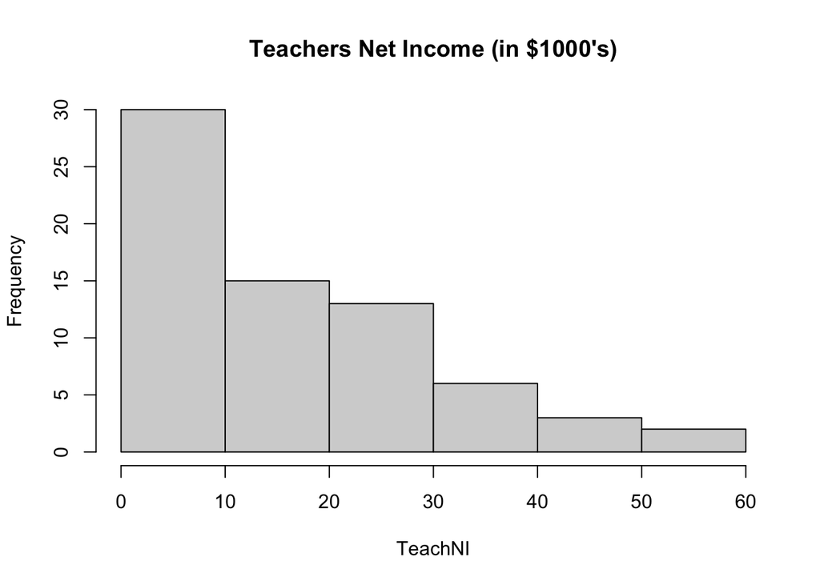

```r
hist(TeachNI, main="Teachers Net Income (in $1000's)")
```

To change the number of bins in the histogram we run the code:

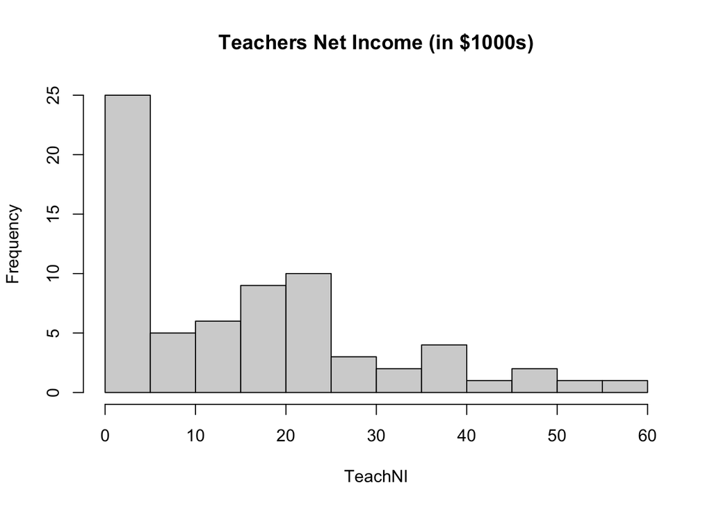

```r
hist(TeachNI,breaks=15, main="Teachers Net Income (in $1000s)")
```

In either plot we are seeing the the data has a long right tail. To do a box-plot we run the code:

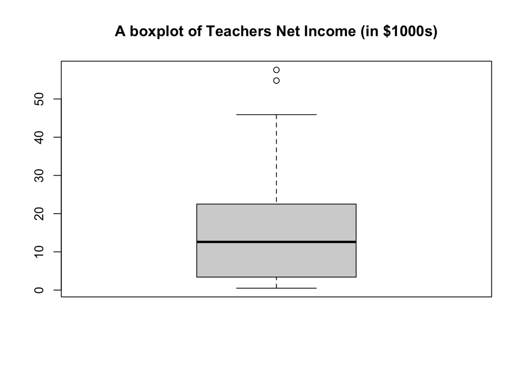

```r
boxplot(TeachNI, main="A boxplot of Teachers Net Income (in $1000s)")
```

```r
summary(BigMac2003)
```

```
##      BigMac           Bread            Rice         FoodIndex
##  Min.   : 10.00   Min.   : 6.00   Min.   : 5.00   Min.   : 23.50
##  1st Qu.: 16.00   1st Qu.:13.00   1st Qu.:12.00   1st Qu.: 41.20
##  Median : 25.00   Median :19.00   Median :16.00   Median : 62.60
##  Mean   : 37.28   Mean   :24.58   Mean   :19.94   Mean   : 61.93
##  3rd Qu.: 48.00   3rd Qu.:28.00   3rd Qu.:22.00   3rd Qu.: 75.30
##  Max.   :185.00   Max.   :90.00   Max.   :96.00   Max.   :129.40
##       Bus             Apt            TeachGI         TeachNI
##  Min.   :0.090   Min.   :  90.0   Min.   : 0.60   Min.   : 0.50
##  1st Qu.:0.360   1st Qu.: 320.0   1st Qu.: 4.10   1st Qu.: 3.40
##  Median :0.830   Median : 700.0   Median :17.80   Median :12.60
##  Mean   :1.041   Mean   : 713.9   Mean   :21.22   Mean   :15.78
##  3rd Qu.:1.490   3rd Qu.: 950.0   3rd Qu.:32.30   3rd Qu.:22.50
##  Max.   :3.700   Max.   :1930.0   Max.   :78.50   Max.   :57.60
##     TaxRate         TeachHours
##  Min.   :-7.317   Min.   :20.00
##  1st Qu.:15.000   1st Qu.:33.00
##  Median :21.739   Median :38.00
##  Mean   :21.482   Mean   :36.74
##  3rd Qu.:28.807   3rd Qu.:40.00
##  Max.   :42.353   Max.   :58.00
```

If we want to find the mean of a specific variable we can do it directly.

```r
mean(TeachNI)
```

```
## [1] 15.77826
```

If we want to find the standard deviation of a variable we can again do it directly.

```r
sd(TeachNI)
```

```
## [1] 14.07626
```

And just for completeness the way we calculate the variance in R is the standard deviation squared.

```r
sd(TeachNI)^2
```

```
## [1] 198.1411
```

```r
var(TeachNI)
```

```
## [1] 198.1411
```

### Calculating P-Values and Quantiles in R

Summary statistics are great, and give us ideas about what is happening with our data, but at the end of it we will actually want to do some inference. We need to be able to calculate confidence intervals and report the results of hypothesis tests.  
In some classes this is taught using charts or tables. For our purposes (since this is a review we are going to discuss calculating probabilities and quantiles from normal and t-distributions.

Specifically, R allows us to approximate $P(X < x^*)$ for any value $x^*$ where $X \sim N(\mu,\sigma)$ using the function

```r
pnorm(q, mean=0,sd=1,lower.tail=TRUE)
qnorm(p,mean=0,sd=1,lower.tail=TRUE)
```

- q is the value of $x^*$
- p is the probability we are searching for
- mean is the mean value, the default is 0
- sd is the standard deviation the default is 1
- lower.tail is a TRUE or FALSE variable that wants to know if values are above or below q, default is TRUE

Lets say we have a random variable $X$ that is distributed $N(1,3)$ (mean of 1, standard deviation of 3). We want to calculate the probability, using this distribution, that we would observe a value that falls above 5. To do this in R we will use the `pnorm` function. Now this is the first time we have seen a function with multiple *arguments*. Each time we need to specify values of `q`, `mean`, `sd`, and `lower.tail`. In reality we can leave all but `q` blank and the defaults will be used for the other values.

To find the probability we are looking for let’s write it out in math $P(X>5)=P(X\geq 5)$. In this equation our distribution has `mean=1`, `sd=3`, and since we are looking for values greater than 5 we will be looking in the upper tail that means `lower.tail=FALSE`.

```r
pnorm(5,mean=1,sd=3,lower.tail=FALSE)
```

```
## [1] 0.09121122
```

Lets say we want to calculate the probability of observing a value below -2 for a standard normal distribution ($Z \sim N(0,1)$). That gives us $P(Z\leq -2)$.

```r
pnorm(-2)
```

```
## [1] 0.02275013
```

```r
 qnorm(.025,mean=0,sd=1,lower.tail=FALSE)
```

```
## [1] 1.959964
```

```r
 qnorm(.975,mean=0,sd=1)
```

```
## [1] 1.959964
```

To calculate the probabilities and quantiles for a t-distribution we will us the functions

```r
qt(p,df, lower.tail=TRUE)
pt(q, df, lower.tail=TRUE)
```

where `df` are the number of degrees of freedom. Just like for the normal we will use `pt` for probabilities and `qt`.

If we want to calculate the probability of observing a value from a $t_40$ (t-distribution with 40 degrees of freedom) that is above 2 we use the code:

```r
pt(2,df=40,lower.tail=FALSE)
```

```
## [1] 0.02616117
```

If we want to calculate the value of the t-distribution with 25 degrees of freedom that places .025 probability in the lower tail we run the code:

```r
qt(.025,df=25,lower.tail=TRUE)
```

```
## [1] -2.059539
```

Now these are the two basic distributions we will use. We will learn two more slightly more complex distributions this semester but for now this is really all we need as far as `` basic statistics”.

We will cover more R as we go but if you understand this document (or most of it) then we have a good enough base to get started. R or any other statistical computational tools are just like anything else, the more repetitions you do the better off you will be.

## Data in R

When managing data in R it is important to understand the types of data R supports. The two most attributes of any data type are the mode and the class of the data. When problems arise with data most of the time it is because the data is in a incorrect mode or class for a particular operation or function. First let’s define an object as anything that is in R, that can be called. From functions to data sets, anything that is contained in R is an R object.

The most common modes of R objects are numeric (numbers), characters (words or letters), logical (True or false) statements and functions (the object is a function). Different types of functions work on different type of modes, for instance some functions will only work on specific types of modes. For instance, can you take a mean of an object of mode type character? Of course not! So part of using data is understanding what type of data you have and how computers work with it.

Classes are slightly different than the mode of an object. A class tells you how the object has been stored in R but also what functions it can interact with.

Let’s look at a few examples:

First let’s look at the number 2

```r
class(2)
```

```
## [1] "numeric"
```

```r
mode(2)
```

```
## [1] "numeric"
```

Next the logical variable TRUE

```r
class(TRUE)
```

```
## [1] "logical"
```

```r
mode(TRUE)
```

```
## [1] "logical"
```

For the character string Hello

```r
class("Hello")
```

```
## [1] "character"
```

```r
mode("Hello")
```

```
## [1] "character"
```

Creating R objects Y and X. The objects on both sides of the assignment operator are R objects.

```r
Y<-runif(10)
X<-runif(10)
```

If we look at the R Object `Y` and the `mean` function of the object we see that

```r
class(Y)
```

```
## [1] "numeric"
```

```r
mode(Y)
```

```
## [1] "numeric"
```

```r
class(mean(Y))
```

```
## [1] "numeric"
```

But if Looking at the mean function by itself we have

```r
mode(mean)
```

```
## [1] "function"
```

To better understand classes lets look at the `lm` function, a function that we would use to run liner regression in R. When we look at the mode and class of the result we see.

```r
mode(lm(Y~X))
```

```
## [1] "list"
```

```r
class(lm(Y~X))
```

```
## [1] "lm"
```

Notice we have an `lm` class, which means the output has a specific form that only `lm` models will have. Think of this as a list of a specific form of `lm`, this allows users to understand how to access elements of the output, and allows R to interact with it in specific ways. There are many types of classes, and most relate to certain packages or types of packages.

### Data Types

We have already seen many data types in R but just haven’t refereed to them in detail. The basics are

- Numeric
- Integer
- Logical (True or False)
- Character (words/ Factor)

We can always check the type of our data by using the `str` function.

```r
library(alr4)
str(salary)
```

```
## 'data.frame':    52 obs. of  6 variables:
##  $ degree: Factor w/ 2 levels "Masters","PhD": 1 1 1 1 2 1 2 1 2 2 ...
##  $ rank  : Factor w/ 3 levels "Asst","Assoc",..: 3 3 3 3 3 3 3 3 3 3 ...
##  $ sex   : Factor w/ 2 levels "Male","Female": 1 1 1 2 1 1 2 1 1 1 ...
##  $ year  : int  25 13 10 7 19 16 0 16 13 13 ...
##  $ ysdeg : int  35 22 23 27 30 21 32 18 30 31 ...
##  $ salary: int  36350 35350 28200 26775 33696 28516 24900 31909 31850 32850 ...
```

If we check that BigMac2003 data set we have

```r
str(BigMac2003)
```

```
## 'data.frame':    69 obs. of  10 variables:
##  $ BigMac    : int  16 21 19 50 22 15 16 93 54 18 ...
##  $ Bread     : int  9 12 19 42 19 7 10 48 20 11 ...
##  $ Rice      : int  9 19 9 25 10 7 16 16 28 12 ...
##  $ FoodIndex : num  65.9 63.5 55.4 46.4 62.9 98.4 64.4 33.3 36.9 74.7 ...
##  $ Bus       : num  2 0.61 1.57 0.47 0.91 2.34 2.21 0.32 0.36 1.5 ...
##  $ Apt       : int  890 620 780 120 590 930 630 200 350 590 ...
##  $ TeachGI   : num  34.3 19.5 22 4.2 25.5 78.5 45 4.1 4.1 30.6 ...
##  $ TeachNI   : num  20.5 15.9 16.1 4 20.1 57.6 28.9 3.9 3.3 18.9 ...
##  $ TaxRate   : num  40.23 18.46 26.82 4.76 21.18 ...
##  $ TeachHours: int  39 29 40 35 39 35 36 41 40 24 ...
```

Also we can always check things such as `is.numeric` or change the data type using `as.numeric`. Note this works for factor, logical, and the rest of the data types.

Notice there is a difference between integers and numeric and then characters and factors.

We also need to understand the different data storage types that are in R. The major ones we will focus on are

- Matrices
- Data frames
- Lists
- Vectors

### Matrices

These data storage types are what we will normally use in R. We just need to make sure we are using it correctly and understand the limitations and how to work with each of these things first thing we need to start with is matrices. Now you’ve probably done some linear algebra at some point in your background, matrices are what you will do these types of functions with. So lets generate a matrix and see the type of functions we can use are

```r
## Generating a 3 by 3 matrix with integers 1 to 9, calling it A
A<-matrix(1:9,nrow=3,ncol=3,byrow=TRUE)
A
```

```
##      [,1] [,2] [,3]
## [1,]    1    2    3
## [2,]    4    5    6
## [3,]    7    8    9
```

```r
B<-matrix(1:9, nrow=3,ncol=3, byrow=FALSE)
B
```

```
##      [,1] [,2] [,3]
## [1,]    1    4    7
## [2,]    2    5    8
## [3,]    3    6    9
```

We see the difference that the `byrow` command makes in creating these matrices. Now let’s check that this is a matrix (lets also check BigMac2003)

```r
is.matrix(A)
```

```
## [1] TRUE
```

```r
is.matrix(BigMac2003)
```

```
## [1] FALSE
```

To transpose the matrix we do

```r
t(A)
```

```
##      [,1] [,2] [,3]
## [1,]    1    4    7
## [2,]    2    5    8
## [3,]    3    6    9
```

To multiply two matrices together we do

```r
A%*%A
```

```
##      [,1] [,2] [,3]
## [1,]   30   36   42
## [2,]   66   81   96
## [3,]  102  126  150
```

```r
## Note %*% is matrix multiplication and * is element wise multiplication
```

Addition and subtraction work element wise in R and are straight forward. Think of vectors as a single row or column element of a matrix.

### Data Frame

Data frames resemble matrices in R but do not function like them. The best way to check if something is a data frame is to use two commands `is.data.frame` or `names`. Since we know BigMac2003 isn’t a matrix we need to check if its a data frame. We do that by

```r
is.data.frame(BigMac2003)
```

```
## [1] TRUE
```

```r
names(BigMac2003)
```

```
##  [1] "BigMac"     "Bread"      "Rice"       "FoodIndex"  "Bus"
##  [6] "Apt"        "TeachGI"    "TeachNI"    "TaxRate"    "TeachHours"
```

The names command shows us what we can call using the atomic operator (the dollar sign). For instance

```r
BigMac2003$BigMac
```

```
##  [1]  16  21  19  50  22  15  16  93  54  18  79  43  45  76  10  16  22  15  15
## [20]  16  19  13  36  67  33 132  84  25  55  79  33  39  16  10  17  15  21  24
## [39]  62  75  10  21  14  30 112 185  12  18  19  42  48  43  26  52  33  28  30
## [58]  21  31  19  19  18  49  31  10  14  15  62  44
```

### Lists

Lists maybe the most useful and robust data type we have. They can contain anything and everything and no problems will be found. For instance if I need a data type to contain multiple vectors of different lengths (different samples) or a description and the data we can use a list. To create a list we do

```r
MyList<-list(A=1:9,B=2:5)
MyList
```

```
## $A
## [1] 1 2 3 4 5 6 7 8 9
##
## $B
## [1] 2 3 4 5
```

To call the list we can do a few different things we can call it just like a data frame (which is a type of list)

```r
names(MyList)
```

```
## [1] "A" "B"
```

```r
MyList$A
```

```
## [1] 1 2 3 4 5 6 7 8 9
```

```r
MyList[[1]]
```

```
## [1] 1 2 3 4 5 6 7 8 9
```

The double brackets allow us to access list elements, and works very much like accessing elements in a vector. Lists are very useful when needing to store different data sets that are associated in some way. Most output of functions, that do more than simple calculations, in R is a list. We’ll learn later how to write functions and access the output.

### Missing Values in R

One of the most important and troubling pieces of working with data is working with missing data. What do you do when your data set is incomplete? How can you deal with it? How should you deal with it? As in everything else with data there is a difference between ideal and reality. Ideally we wouldn’t have missing data, we wouldn’t have problems to deal with. We first need to figure out how to identify these problems, first lets see what it looks like in R

```r
Data<-data.frame(x1=c(1,3,NA,4,5), x2=c(NA,NA,"red","green","blue"))
Data
```

```
##   x1    x2
## 1  1  <NA>
## 2  3  <NA>
## 3 NA   red
## 4  4 green
## 5  5  blue
```

In R `NA` will denote a missing value. Notice the difference when we have a character variable and a integer variable. We see the `<NA>` in the case of the character and just `NA` in the case of the integer. It is easy to see the missing values in this type of data set but what about when they aren’t so easy to see in a large data set how will we know they exist?

The easiest way is to use the `is.na` function in R

```r
is.na(Data$x1)
```

```
## [1] FALSE FALSE  TRUE FALSE FALSE
```

```r
any(is.na(Data$x1))
```

```
## [1] TRUE
```

The question is what do we do with the entire data set

```r
is.na(Data)
```

```
##         x1    x2
## [1,] FALSE  TRUE
## [2,] FALSE  TRUE
## [3,]  TRUE FALSE
## [4,] FALSE FALSE
## [5,] FALSE FALSE
```

```r
any(is.na(Data))
```

```
## [1] TRUE
```

This still doesn’t get us around what to do with it, how will it effect our functions, and what can we do to remove all the data points with `NA`. To remove all the data points with `NA` we use the function.

```r
na.omit(Data$x1)
```

```
## [1] 1 3 4 5
## attr(,"na.action")
## [1] 3
## attr(,"class")
## [1] "omit"
```

```r
na.omit(Data$x2)
```

```
## [1] "red"   "green" "blue"
## attr(,"na.action")
## [1] 1 2
## attr(,"class")
## [1] "omit"
```

```r
na.omit(Data)
```

```
##   x1    x2
## 4  4 green
## 5  5  blue
```

Notice if we need both `x1` and `x2` to not have `NA` then we only have two observations, but individually we would get more. What about if we want to take the mean of `x1`? Would it work?

```r
mean(Data$x1)
```

```
## [1] NA
```

```r
mean(na.omit(Data$x1))
```

```
## [1] 3.25
```

The answer is no, but if we omit the `NA`’s we get the mean. It is important to understand where your missing data is and how your code will react to it.

## Random Number Generation in R

### Why Generate Numbers Randomly

In statistics we discuss and try to understand variation in our data. The hope is part of that variation can be explained by some factor or variable we already know, but once that is accounted for we still have randomness that needs understood. Randomly generating numbers (it is really pseudo random number generation) allows us to see what the randomness in our data looks like, and possibly give us a comparison for our method. Another reason to randomly generate data is to check to see if method we develop (or need to program) actually work. In almost every statistical paper you also see what we call ``proof by simulation”. This means we show that methods work when data comes from a certain statistical model or various statistical models, it also shows when they will not work.

For us we really need to understand how to do three things (for right now)

- Sample data points from an existing data set
- Generate data from any distribution (conceptually)
- Generate data from a normal distribution

`sample` function

Let’s say we want to randomly sample 5 numbers from the the numbers $\{1,2,3,\ldots,20\}$, and any number can only show up at most one time in the sample. How would we do this in `R` ? What is the mathematical question even?

The mathematical question is where we start. We want to randomly sample 5 numbers without replacement of the set $\[1,2,\ldots,20\}$, where each number is sampled with equal probability. Remember without replacement means once a number is selected it can not be selected again. To do this in R we use the `sample` function which has arguments of `x`, which is the set we want to sample, `size`, which is the number of point we want to return, and `replace` which is a logical statement (`TRUE` or `FALSE`) which that says whether to sample with or without replacement. We also need to set the seed, a seed is the argument that initializes the random number generator (or random sampling). By setting the seed we guarantee that our set of numbers and our results can be reproduced, this means if you know my seed and have my code you could reproduce my results. To answer our question we use the following code

```r
set.seed(10)
Out1<-sample(1:20,5,replace=FALSE)
Out1
```

```
## [1] 11  9 10 16 12
```

So why would we want to do something like this? There are certain methods such as bootstrapping and randomization testing that require us to sub sample our data. This method will be useful as we move forward.

### Generating Data from a Probability Distribution

Sometimes just sampling numbers 1 to 20 isn’t enough we need to be able to generate data from any type of probability distribution. The method we are going to learn is known as the Inverse CDF method.
If we want to generate data from any probability distribution than we need to understand the basic properties of any probability density function. The major property we need to use is that all probabilities are between 0 and 1. To be a little more rigorous. Define $X$ to be a random variable with probability density function (pdf) $g(X)$ and cumulative density function $G(X)$. Just as a reminder this means that
$$\begin{equation*}
P(X\leq x)=\int_{\inf}^x g(x)=G(x).
\end{equation*}$$

So using this idea we only need to be able to generate data from a continuous uniform distribution and use that to generate a value that corresponds to a quantile in our distribution. So here is what our process looks like

- Randomly generate a value from a uniform distribution with minimum 0 and maximum 1. Let’s call this value $p$.
- Find the quantile associated with $p$ using the probability distribution of your choice think of this as $G^{-1}(p)$.

For example if I wanted to do this in R and generate 10 data points from a $N(0,1)$ I would do the following

```r
set.seed(10)
M<-runif(10,0,1)
M
```

```
##  [1] 0.50747820 0.30676851 0.42690767 0.69310208 0.08513597 0.22543662
##  [7] 0.27453052 0.27230507 0.61582931 0.42967153
```

```r
qnorm(M)
```

```
##  [1]  0.01874617 -0.50503107 -0.18425255  0.50466259 -1.37133055 -0.75396001
##  [7] -0.59916772 -0.60585637  0.29454513 -0.17721050
```

To do it in fewer steps we would do

```r
set.seed(10)
qnorm(runif(10,0,1))
```

```
##  [1]  0.01874617 -0.50503107 -0.18425255  0.50466259 -1.37133055 -0.75396001
##  [7] -0.59916772 -0.60585637  0.29454513 -0.17721050
```

So intuitively we could do this with any distribution. The good news is that the brand name distributions are already pre-programmed in R. So we don’t need to use the inverse CDF method in all cases. For instance if we want to generate 10 data points from a standard normal distribution ($N(0,1)$ you may have heard this called the $Z$ distribution) in R we do

```r
X<-rnorm(10)
X
```

```
##  [1]  0.3897943 -1.2080762 -0.3636760 -1.6266727 -0.2564784  1.1017795
##  [7]  0.7557815 -0.2382336  0.9874447  0.7413901
```

Final thing to note is that you see the `set.seed` function in R, what this does is creates reproducible random numbers in R. Basically it starts your random number generator at a certain spot so you can produce the same random numbers at each spot for instance watch what happens when I do this.

```r
set.seed(10)
rnorm(2)
```

```
## [1]  0.01874617 -0.18425254
```

```r
set.seed(11)
rnorm(2)
```

```
## [1] -0.59103110  0.02659437
```

```r
set.seed(10)
rnorm(2)
```

```
## [1]  0.01874617 -0.18425254
```

```r
rnorm(2)
```

```
## [1] -1.3713305 -0.5991677
```

Any time we do any type of random number generation we should set our seed, for reproducibility purposes. Why is reporducibility so important? as you’ll see as we move forward most modern methods depend at some point on random number generation, so we need to make sure that we can obtain the same result. Also it gives us a way to test the sensitivity, if the results are the same across many different sets of random numbers the result is probably consistent. You’ll see this used all across your statistics and data mining courses, so it is important that you understand this fundamental concept.

##The Apply Functions

In R we typically work with data frames, which we can think of as a list that reports like a matrix, or an excel file that you see. You can also think of it as multiple vectors where each element of the vector corresponds to the same observations in the data (i.e. The first data point in the first and second vector are describing an attribute of the same person). We have previously discussed simple ways of subsetting these observations and being able to look at rows, columns, and any combination individually. In data frames that are of substantial size though sometimes what we care about is a summary of the data (i.e. mean of each variable, standard deviation of each variable). We could also want to know about these same summary statistics of each subpopulation represented in the data we have. To do this in R we have a class of functions which are known as the apply functions. Here we will do a brief introduction to these functions and show you some quick examples.

Again for simplicity we will use the `alr4` package, due to the vast amount of data the package contains.

### `apply` Function}

The `apply` function in R allows you to apply a function to the rows or columns of a matrix, in our case that would refer to the observations or variables. This can be useful for a lot of reasons to see one lets return to the BigMac2003 data set we have previously used.

```r
library(alr4)
data(BigMac2003)
head(BigMac2003)
```

```
##           BigMac Bread Rice FoodIndex  Bus Apt TeachGI TeachNI TaxRate
## Amsterdam     16     9    9      65.9 2.00 890    34.3    20.5 40.2332
## Athens        21    12   19      63.5 0.61 620    19.5    15.9 18.4615
## Auckland      19    19    9      55.4 1.57 780    22.0    16.1 26.8182
## Bangkok       50    42   25      46.4 0.47 120     4.2     4.0  4.7619
## Barcelona     22    19   10      62.9 0.91 590    25.5    20.1 21.1765
## Basel         15     7    7      98.4 2.34 930    78.5    57.6 26.6242
##           TeachHours
## Amsterdam         39
## Athens            29
## Auckland          40
## Bangkok           35
## Barcelona         39
## Basel             35
```

There are certain variables that are in the same units that we could want to do some basic summary statistics on.  
For instance we may want to compare the mean price of Bread, Rice, and BigMac. We can calculate this in multiple ways but for this discussion we will on focus on using the apply function. The use of the apply function looks like

```r
apply(MyMatrix, index, function)
```

where

- `MyMatrix` is your data matrix or data frame
- `index` refers to either the columns or rows. This argument only responds to 1 (rows) or 2 (columns). Think of this as a row by column statement. We always say rows first and columns second.
- `function` refers to the function you want to apply to either the rows or the columns. This can either be a pre-programmed (cookbook) function in R OR you can write your own function to place here. Note the argument of this function needs to be a data vector or the apply function becomes more complex.

Now to see how it applies to the BigMac2003 data we can use the code

```r
apply(BigMac2003,2, mean)
```

```
##     BigMac      Bread       Rice  FoodIndex        Bus        Apt    TeachGI
##  37.275362  24.579710  19.942029  61.930435   1.041159 713.913043  21.220290
##    TeachNI    TaxRate TeachHours
##  15.778261  21.481858  36.739130
```

Notice a few things about the code. The data set or matrix that we are using is BigMac2003, we wanted to mean of the variables which corresponds to index 2, and finally we are using the mean function (which is already in R.

This gives all the mean of all variables there are two ways just to see the first 3 if we only want those. Both are basic subsetting techniques. We can either subset the data or subset the result such as

```r
apply(BigMac2003[,1:3],2,mean)
```

```
##   BigMac    Bread     Rice
## 37.27536 24.57971 19.94203
```

```r
apply(BigMac2003,2,mean)[1:3]
```

```
##   BigMac    Bread     Rice
## 37.27536 24.57971 19.94203
```

In either case the result is the same. The speed of the code in this case isn’t an issue since this is a fairly small data set and mean is a very efficient function in R.

### `tapply` Function}

The `tapply` function is used to differentiate between existing sub-populations you can find in your data. Let’s say we want to understand the means of men and women in a marketing survey, or from a salary perspective (if you work in HR). To give an example of this lets look at the `salary` data. This data is salary data for professors at a small mid-western college. We want to understand a the mean in certain sub populations of this data. Loading and looking at the variables involved

```r
data(salary)
head(salary)
```

```
##    degree rank    sex year ysdeg salary
## 1 Masters Prof   Male   25    35  36350
## 2 Masters Prof   Male   13    22  35350
## 3 Masters Prof   Male   10    23  28200
## 4 Masters Prof Female    7    27  26775
## 5     PhD Prof   Male   19    30  33696
## 6 Masters Prof   Male   16    21  28516
```

One of the things we could be interested in is pay differential between males and females. The easiest way to do this is use the `tapply` function. The use of the `tapply` function is

```r
tapply(data, variable, function)
```

where

- data is the variable you are interested in calculating
- variable is the variable you wish to subset on
- function is the function you want applied to the data

To look use this on our data we want to look at the salary difference between males and females. To do that we use the code

```r
tapply(salary$salary, salary$sex, mean)
```

```
##     Male   Female
## 24696.79 21357.14
```

Now lets say we wanted to look at a comparison of the distribution of the data for each of these sub populations we would do

```r
tapply(salary$salary, salary$sex, summary)
```

```
## $Male
##    Min. 1st Qu.  Median    Mean 3rd Qu.    Max.
##   16094   20606   24746   24697   28200   36350
##
## $Female
##    Min. 1st Qu.  Median    Mean 3rd Qu.    Max.
##   15000   16827   20495   21357   24288   38045
```

Another function we may want to use is `split` which will split the variable into two different data sets (a list which will will talk about in a different section). For instance if we want to split the data set for analysis based on gender (for simplicity we will only do salary) we would do

```r
split(salary$salary, salary$sex)
```

```
## $Male
##  [1] 36350 35350 28200 33696 28516 31909 31850 32850 27025 24750 28200 23712
## [13] 25748 29342 31114 24742 22906 24450 19175 20525 27959 24832 25400 24800
## [25] 26182 23725 23300 23713 20850 17095 16700 17600 18075 18000 20999 16500
## [37] 16094 16244
##
## $Female
##  [1] 26775 24900 38045 25500 21600 20690 22450 18304 17250 16150 15350 16686
## [13] 15000 20300
```

We can see this splits the data set into salaries for males and salaries for females.

The last of the apply functions we will talk about for the moment is the `lapply` function. It allows you to apply a function to elements of lists. So for instance if we want the mean of each element of our created list we use the code

```r
lapply(MyList,mean)
```

```
## $A
## [1] 5
##
## $B
## [1] 3.5
```

```r
sapply(MyList,mean)
```

```
##   A   B
## 5.0 3.5
```

Notice `lapply` returns a list, while sapply returns a vector. This is where understanding what you’re dealing with inside of the programming language matters.

You’ll need to have all of this to work through the computational methods we will discuss.

## `for`, `if`, `while` Statements

Up to this point we have just accessed data, and understand the data types we want. What if we want to design a matrix with a specific structure. For instance if we want to create what is known as an Auto Regressive 1 correlation structure denoted as $AR_\rho(1)$ the $i,j$th element of the matrix we need to use a for loop. Just as in any programming language for works when you have a fixed amount of iterations that you know you need (i.e. a matrix). Lets say we want to know the sum of the numbers 1 to 20. We can do it simply in a for loop.  
*NOTE R starts indexing at 1 not 0 like some other languages*

```r
## Intializing a sum counter
Sum=0
for(i in 1:20){
Sum=Sum+i
}
Sum
```

```
## [1] 210
```

```r
## Another way to do this
sum(1:20)
```

```
## [1] 210
```

What this code does is for each integer between (and including) 1 to 20 it adds it together.

The `while` statement does something slightly different it can be used when you know when you need your algorithm to stop but you don’t know exactly how to do it. Let’s say we want to stop a statement when our sum exceeds 100, but we aren’t sure how many iterations that takes. We set up the code like this

```r
Sum=0
iter=0
while(Sum<100){
iter=iter+1
Sum=Sum+iter
}
Sum
```

```
## [1] 105
```

```r
iter
```

```
## [1] 14
```

Notice we can see how many iterations of our algorithm it took to get to exceed 100, and check what the sum came out too.

While looks can be thought of as `` do this WHILE this (my termination statement) is true/false”. An if statement can be thought as of one pass of a while loop, if this statement is true do this if it isn’t don’t do anything. For instance

```r
Sum=0
if(Sum==0){
Sum=1000
iter=1
}
Sum
```

```
## [1] 1000
```

```r
iter
```

```
## [1] 1
```

If we run the same code but turn it to not equal we have

```r
Sum=0
if(Sum!=0){
Sum=1000
iter=1
}
Sum
```

```
## [1] 0
```

```r
iter
```

```
## [1] 1
```

Note that `==` indicates logical equality, `!=` is logical inequality, greater than or equal to `>=`, greater `>`, less than `<`, less than or equal to `<=`.

A few other things you should know `&` represent and conditional statements. For an OR conditional statement we use`|`. It works comparing a single statement or entire vectors.

```r
((-2)>=0 & (2)<=0)
```

```
## [1] FALSE
```

```r
((-2:2)>=0 & (-2:2)<=0)
```

```
## [1] FALSE FALSE  TRUE FALSE FALSE
```

### Introduction to the Tidyverse and the Pipe Operator

Now that we understand some of the basics in R let’s start looking at some of the modern developments in R. The “Tidyverse” as it is known are a set of packages that allow for a more simplistic workflow. One of the main operators we’re going to look at in this case ins the `%>%` operator which is known as the pipe operator, also known as the forward pipe operator. What this operator does is take the proceeding element and feed into the following function. Let’s take a look at something very simple you learned in a previous section:

```r
library(alr4)
library(dplyr)
BigMac2003%>%head()
```

```
##           BigMac Bread Rice FoodIndex  Bus Apt TeachGI TeachNI TaxRate
## Amsterdam     16     9    9      65.9 2.00 890    34.3    20.5 40.2332
## Athens        21    12   19      63.5 0.61 620    19.5    15.9 18.4615
## Auckland      19    19    9      55.4 1.57 780    22.0    16.1 26.8182
## Bangkok       50    42   25      46.4 0.47 120     4.2     4.0  4.7619
## Barcelona     22    19   10      62.9 0.91 590    25.5    20.1 21.1765
## Basel         15     7    7      98.4 2.34 930    78.5    57.6 26.6242
##           TeachHours
## Amsterdam         39
## Athens            29
## Auckland          40
## Bangkok           35
## Barcelona         39
## Basel             35
```

The way we can think about this result is that it’s the same as saying `head(BigMac2003)`. It doesn’t seem like it’s going to save us much, but it turns out that when we are sub-setting, or working through larger workflows it can actually simplify what we are doing.

Let’s take a look at new data set here just to get a feel for some functionality of the `dplyr` package, which is a BIG part of the tidyverse, and is a major package used for data manipulation.

```r
iris%>%head()
```

```
##   Sepal.Length Sepal.Width Petal.Length Petal.Width Species
## 1          5.1         3.5          1.4         0.2  setosa
## 2          4.9         3.0          1.4         0.2  setosa
## 3          4.7         3.2          1.3         0.2  setosa
## 4          4.6         3.1          1.5         0.2  setosa
## 5          5.0         3.6          1.4         0.2  setosa
## 6          5.4         3.9          1.7         0.4  setosa
```

```r
iris%>%dim()
```

```
## [1] 150   5
```

#### `dplyr`: `filter`

Next let’s look and the filter function. The first argument of the `filter` function is what data frame we want to filter, and if we’re using pipes, that will be what is passed by the pipes. So the second argument is the name of the variable and how we want it filtered. So think of it this way.

```r
filter(data frame, variable1 condition)
```

Now let’s look at an example and I’m going to use a pipe to pass the data frame so we only need to focus on the variable and the condition. I want to filter the data so we are only looking at setosa’s.

```r
seosta_only=iris%>% filter(Species=="setosa")
seosta_only
```

```
##    Sepal.Length Sepal.Width Petal.Length Petal.Width Species
## 1           5.1         3.5          1.4         0.2  setosa
## 2           4.9         3.0          1.4         0.2  setosa
## 3           4.7         3.2          1.3         0.2  setosa
## 4           4.6         3.1          1.5         0.2  setosa
## 5           5.0         3.6          1.4         0.2  setosa
## 6           5.4         3.9          1.7         0.4  setosa
## 7           4.6         3.4          1.4         0.3  setosa
## 8           5.0         3.4          1.5         0.2  setosa
## 9           4.4         2.9          1.4         0.2  setosa
## 10          4.9         3.1          1.5         0.1  setosa
## 11          5.4         3.7          1.5         0.2  setosa
## 12          4.8         3.4          1.6         0.2  setosa
## 13          4.8         3.0          1.4         0.1  setosa
## 14          4.3         3.0          1.1         0.1  setosa
```

[output cut: 36 more lines]

Next let’s look at an example where we want to filter a continuous variable like Petal.Length

```r
long_petals=iris%>% filter(Petal.Length>1.5)
head(long_petals)
```

```
##   Sepal.Length Sepal.Width Petal.Length Petal.Width Species
## 1          5.4         3.9          1.7         0.4  setosa
## 2          4.8         3.4          1.6         0.2  setosa
## 3          5.7         3.8          1.7         0.3  setosa
## 4          5.4         3.4          1.7         0.2  setosa
## 5          5.1         3.3          1.7         0.5  setosa
## 6          4.8         3.4          1.9         0.2  setosa
```

#### `dplyr`:`select`

The `select` function allows us to subset a set of variables from the data frame. Think of this as doing a column reduction of the data set by name. So the function sets up nicely as

```r
select(data frame, varaible1, variable2, ....)
```

Now let’s just select the sepal variable from the iris data set.

```r
subs=iris%>% select(Sepal.Length,Sepal.Width)
head(subs)
```

```
##   Sepal.Length Sepal.Width
## 1          5.1         3.5
## 2          4.9         3.0
## 3          4.7         3.2
## 4          4.6         3.1
## 5          5.0         3.6
## 6          5.4         3.9
```

##### `dplyr`:`group_by`

The `group_by` function just orders data by a factor, so below we just want to order our data by `Species`.

```r
keep=iris%>%group_by(Species)
head(keep)
```

```
## # A tibble: 6 × 5
## # Groups:   Species [1]
##   Sepal.Length Sepal.Width Petal.Length Petal.Width Species
##          <dbl>       <dbl>        <dbl>       <dbl> <fct>
## 1          5.1         3.5          1.4         0.2 setosa
## 2          4.9         3            1.4         0.2 setosa
## 3          4.7         3.2          1.3         0.2 setosa
## 4          4.6         3.1          1.5         0.2 setosa
## 5          5           3.6          1.4         0.2 setosa
## 6          5.4         3.9          1.7         0.4 setosa
```

#### `dplyr`:`arrange`

The `arrange` function is another way to order a continuous variables, this time we’ll choose to do it in descending order

```r
me=iris%>% arrange(desc(Petal.Length))
head(me)
```

```
##   Sepal.Length Sepal.Width Petal.Length Petal.Width   Species
## 1          7.7         2.6          6.9         2.3 virginica
## 2          7.7         3.8          6.7         2.2 virginica
## 3          7.7         2.8          6.7         2.0 virginica
## 4          7.6         3.0          6.6         2.1 virginica
## 5          7.9         3.8          6.4         2.0 virginica
## 6          7.3         2.9          6.3         1.8 virginica
```

#### `dplyr`:`summarise`

The `summarize` function allows you to create summary statistics of each of these variables. In this case we want to count each species and then return each sepal length.

```r
m2<-iris%>%group_by(Species)%>% summarise(
  n=n(),
  mean_s_length=mean(Sepal.Length)
)
m2
```

```
## # A tibble: 3 × 3
##   Species        n mean_s_length
##   <fct>      <int>         <dbl>
## 1 setosa        50          5.01
## 2 versicolor    50          5.94
## 3 virginica     50          6.59
```

Right now your head my be spinning a little and that is ok. There are many options in R, and many ways to do the same things. The important part is to know where to start and that is what we have done here. We’ve started to lay the foundations for you to know how to learn R and where to begin your journey. Notice we can use any of these anytime.

## Bootstrap

Statistical inference the process of drawing conclusions about the entire population based on the information in the sample. The whole ideas is we want to use statistics from our sample to make estimates (and draw conclusions) about parameters from our population. Statistical inference has two common components, confidence intervals, and hypothesis tests. To understand how to use bootstrap and randomization testing methods, we first need to really understand what is statistical inference and some of the definitions that come with it. Below are some examples.

- Sample Mean $\rightarrow$ True Mean
- Sample Sd $\rightarrow$ True Sd
- Sample Min $\rightarrow$ True Minimum
- Sample Max $\rightarrow$ True Max
- Sample Regression Line $\rightarrow$ True Mean Function

### Parameter

Parameters are fixed values (there is only one population mean) that are unknown in practial settings. The whole idea is we want to use a sample statistic, (sample mean, sample standard deviation) to talk about the population parameters. We have to imagine our data comes from a distribution with a fixed parameter, think a normal distribution with mean of 3, and our data, the stuff we actually observe, is sampled from this distribution so we know that our sample statistic with vary from sample to sample. Think about if you go out and give an online survey (possibly the worst kind of survey) and you spread it over social media on Monday then close it, and then give it again the next Monday at the same time etc. We could think of this data as coming from the same population, but we would expect that the numbers that we’d obtain from the sample data would be different. If the data isn’t highly variable they should be close to one another but having the exact same sample statistics would be unlikely. This idea leads to the thought process behind sampling distributions.

### Sampling Distribution

The *sampling distribution is the distribution of how the sample statistic varies from sample to sample*, it depends on the true parameter and the sample size. As sample size increases our precision will increase and distribution will close in on the true parameter value. This is the whole idea of the law of large numbers (LLN). *LLN says that the more data we have the better estimate we get*. Let’s take a second to discuss/think about this, let’s say a population has 1000 possible data points we could sample in it, so the population size is 1000, we take multiple samples of 900, we wouldn’t think that the samples would vary that much, because AT MOST we are only adding 100 new data points in the second sample that we didn’t have in the first. What if we only had 50 observations in each sample, then the variation we could see would change sample to sample. The idea is that this distribution doesn’t have fixed properties, and it changes based on your sample size. Think about what this means with the rise of “big data”, if sampling distributions (what inference depends on) depend on sample size how does big data play into this. More on this later.

We define a *point estimate as a single estimate for a parameter*. This is the number that you get from your sample statistic from your data, remember an estimator is the equation we use, it becomes an estimate once we plug the data in and get a single number. One of the simplest example you can think of is that we can randomly select 100 residents of USA and find their average income is $40,000. Then our point estimate for the average income of an USA resident is $40,000.

Is it enough just to talk about the sample statistic? In reporting cultures (old school analytics) this is what people do, they come up with a single estimate and run with it. In today’s world this really isn’t sufficient, but my guess is you what more information than me just saying that. So let me put you in a situation that I’ve been put in. I want you to predict the sales (to the dollar) that a multinational will have on the books by end of year, and to make things “easy” I’m asking you to do this in June, so you know half of the year already. Let’s take it one step further and say this is your first project for the organization, which means you need to show off your skills and add credibility. Are you willing to put your reputation/job on the line for a point estimate, a single number, or would you rather be able to give a range of numbers that you could be confident in. In reality this is why we give intervals. We need to report a confidence interval which has the general form of

point estimate $\pm$ margin of error

The margin of error reflects the uncertainty of the point estimate, and has a connection to the sampling distribution, because it gives us a feel for the randomness that the point estimate comes with.

### Bootstrapping

The idea has always been that we have CLT’s to define sampling distributions theoretically, which is probably what you’ve discussed in previous stats classes and what we discussed in the bootcamp.  
In theory (as the sample size gets bigger) our sampling distributions approach the CLT, that’s the main idea of this entire thing, but we’re not talking about theory we’re talking about we’re talking about practice. So is there a way to use the sample we collected to get an idea what the sampling distribution is? The answer is yes and the methodology we use is called *bootstrap*.

You know from previous discussions that the sampling distribution of statistic could be found if you would go out and collect multiple samples from the same population and report the sample statistic, and then evaluate the distribution. Again theoretically this would allow us to look at everything we need to, but what are the problems with it. Well let’s say it takes 4 days and thousands of dollars for a call center to collect 200 respondents to a survey, do you really want to spend money and time to collect the 100 more samples you would need? It would be very time consuming and costly, but the question is what do you do?

In real life you can only collect one sample. So how can you determine the distribution of the sample statistic? *Use your sample*.

- If your sample was random. It should be a reasonable representation of the population distribution.
- We can then re-sample from your sample to create a sampling distribution.
- Idea is treat our sample like it represents the population.

### How to Bootstrap

We are interested in estimating some parameter $\theta$ (say $\mu$ for example) and use our sample to get an estimate $\hat{\theta}$ (or $\bar{x}$ to estimate $\mu$). However we want more than a point estimate. We want to create a confidence interval for reasonable values of $\theta$.

We will use the bootstrap method. First decide how many bootstrap samples you want to do. The more the better and computing has made this easy. Let $n$ be the size of our original sample size and let $k$ be the number of bootstraps we want to do.

1. Re-sample $n$ data points with replacement from the original sample.
2. With your new sample calculate a new sample statistic for each bootstrap sample.
3. Repeat $k$ times until you have $k$ bootstrap statistics.

Now you have a list of bootstrap estimates

$$B_{\mbox{List}} = \left( B_1, ...., B_k\right) \mbox{ or re-order to
get} \\
B_{\mbox{Ordered List}} = \left( B_{(1)},..., B_{(k)}\right),$$
where $B_{(1)}$ is the minimum and $B_{(k)}$ is the maximum of the statistics.
Note this whole procedure depends on your original sample and the statistic you’re trying to bootstrap. Simple problem k = 10,000 takes a couple of seconds. Complicated problem k = 1,000 takes a day.

### After the bootstrap

After we’ve obtained the bootstrap distribution we should plot it to see if the distribution looks smooth, that is there aren’t big gaps in the histogram, or density curve. From there it is easy enough to create confidence intervals. There are two ways to do this. The first is just to pull the quantiles from the sampling distribution you created, the second is to use the bootstrap standard error, standard deviation of the bootstrap sampling distribution, and create a confidence interval using the point estimate.

If the interval is bell shaped, both will produce similar results, if it’s not bell shaped we know we should us the quantiles rather than the standard formulation.

Some notes about bootstrap:

- Requires computing: we will talk more about how to do this in R. Now you see why we spent most of this section discussing computing.
- Original estimate should be in the center of your bootstrap sample. If not there is probably a coding error.
- Bootstrap is better for small $n$ problems but does not solve them and should be treated with some caution.
- Bootstrap depends on sample. +Sample biased then bootstrap results biased.
  - Sample is bad then bootstrap inference will be bad.

### Correct Interpretation

Let’s say we want to do a 95% CI.

- The method I used, including the data collection, will capture the population parameter 95% of the time.
- Usually this statement is used: I am 95% confident the interval contains the population parameter.

### Atlanta Commute Example

*CommuteAtlanta* is a data set about the commute time for Atlanta. Say we are interested in relocating to a specific site in Atlanta, and we want to find the average commute time for someone in Atlanta to understand employee productivity. Load the data

```r
atl <- read.csv("https://www.lock5stat.com/datasets1e/CommuteAtlanta.csv")
head(atl)
```

```
##      City Age Distance Time Sex
## 1 Atlanta  19       10   15   M
## 2 Atlanta  55       45   60   M
## 3 Atlanta  48       12   45   M
## 4 Atlanta  45        4   10   F
## 5 Atlanta  48       15   30   F
## 6 Atlanta  43       33   60   M
```

Let’s take a look at a few visuals just to get a feel of whats happening here.

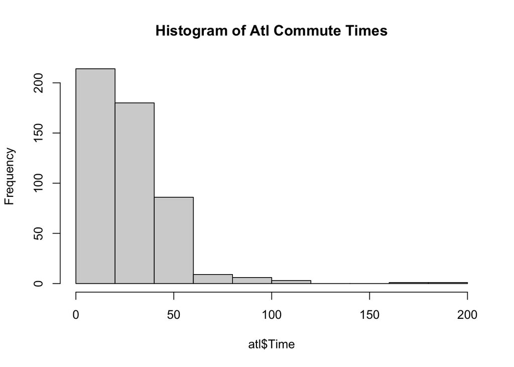

```r
hist(atl$Time, main="Histogram of Atl Commute Times")
```

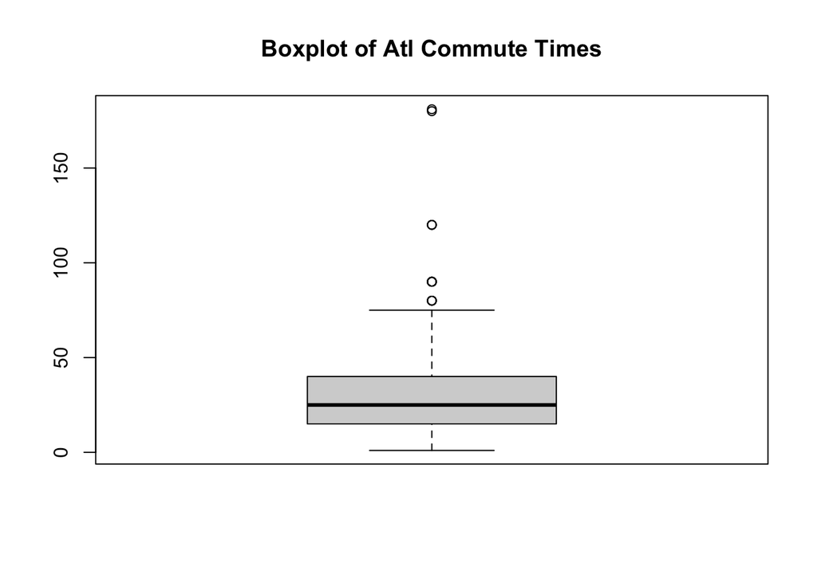

```r
boxplot(atl$Time, main="Boxplot of Atl Commute Times")
```

No we’re going to create the bootstrap sampling distribution. The idea is we resample and then calculate the mean directly, then store it in a vector called `boots`. Notice that we initialize `boots` as `NULL`, this allows us to create the object for storage, but leaves it empty. R knows it’s there and something we can call directly, but it’s just empty. We’ll run a bootstrap example

```r
set.seed(2016)
atlTime <- atl$Time
mean(atlTime)
```

```
## [1] 29.11
```

```r
sd(atlTime)
```

```
## [1] 20.71831
```

```r
length(atlTime)
```

```
## [1] 500
```

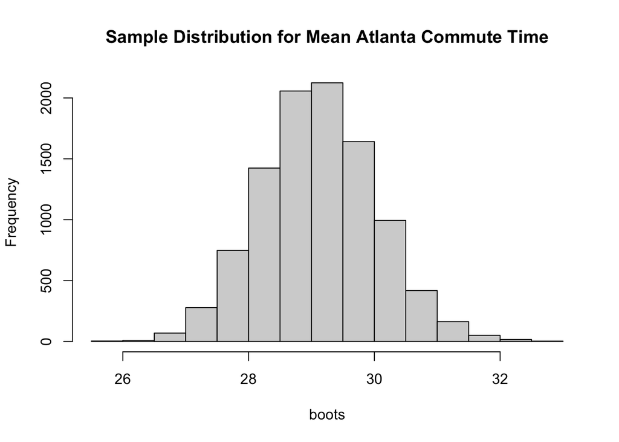

```r
boots <- NULL
for(i in 1:10000){
  meanAtl <- mean( sample(atlTime, 500, replace=TRUE))
  boots <- c(boots, meanAtl)
}
hist(boots, main="Sample Distribution for Mean Atlanta Commute Time")
```

Looks symmetric so we’ll use both intervals anyways.

```r
quantile(boots, c(.025,.975))
```

```
##     2.5%    97.5%
## 27.36200 30.96605
```

```r
mean(atlTime) + 2*c(-sd(boots), sd(boots))
```

```
## [1] 27.27328 30.94672
```

```r
mean(boots)
```

```
## [1] 29.11034
```

```r
sd(boots)
```

```
## [1] 0.9183605
```

How do we interpret these intervals, what does it say about the commute time? Is this interval on the commute times or the mean commute time?

### Removing Outliers

For sensitivity analysis purposes let’s say we only want to look at commute times under 90 minuets. Let’s see if anything changes

```r
atlQuicker <- subset(atl, Time <= 90)
atlQuickTimes <- atlQuicker$Time
mean(atlQuickTimes)
```

```
## [1] 27.94747
```

```r
sd(atlQuickTimes)
```

```
## [1] 17.00825
```

```r
length(atlQuickTimes)
```

```
## [1] 495
```

Lets look at the data again:

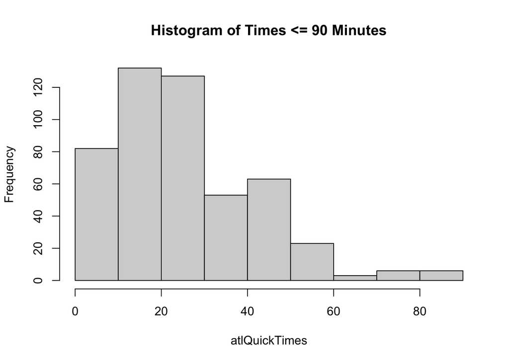

```r
hist(atlQuickTimes, main="Histogram of Times <= 90 Minutes")
```

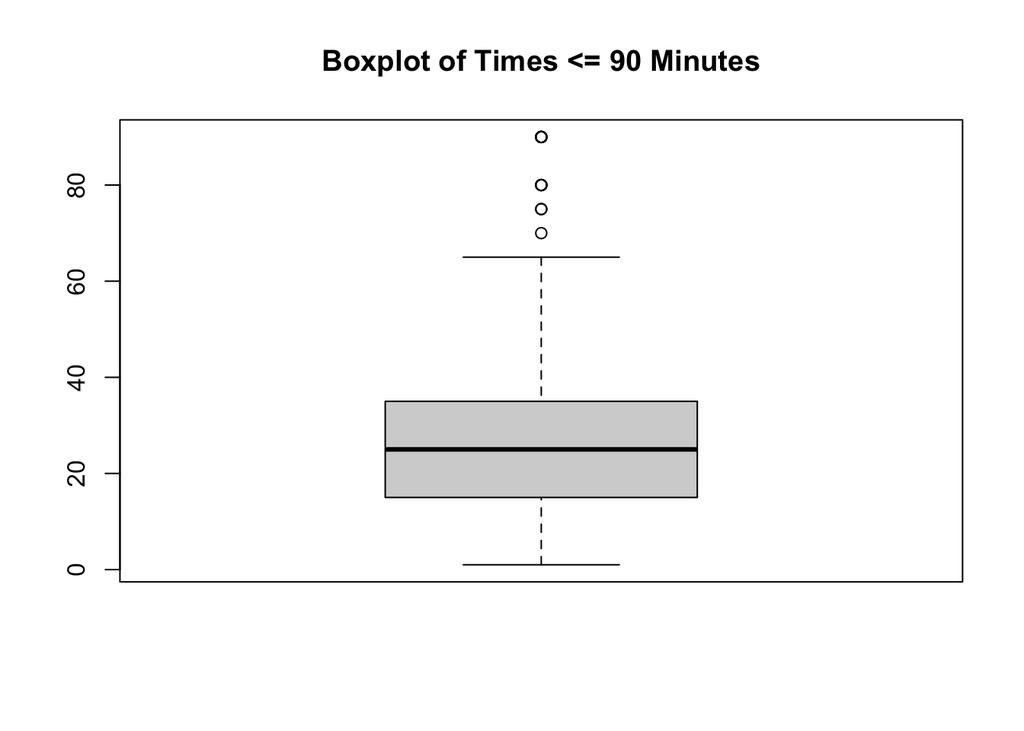

```r
boxplot(atlQuickTimes, main="Boxplot of Times <= 90 Minutes")
```

Now lets do the bootstrap approach

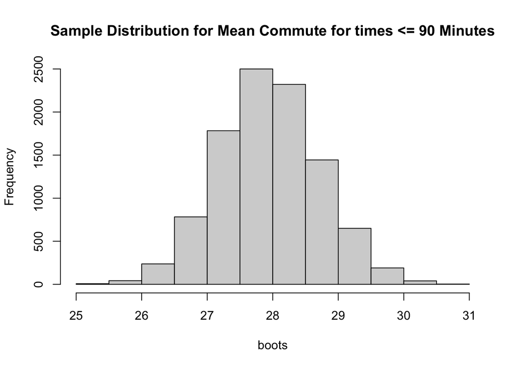

```r
set.seed(2016)
boots <- NULL
for(i in 1:10000){
  meanQuickAtl <- mean( sample(atlQuickTimes, 495, replace=TRUE))
  boots <- c(boots, meanQuickAtl)
}
hist(boots, main="Sample Distribution for Mean Commute for times <= 90 Minutes")
```

Finally let’s create the intervals

```r
quantile(boots, c(.025,.975))
```

```
##     2.5%    97.5%
## 26.45859 29.48283
```

```r
mean(atlQuickTimes) + 2*c(-sd(boots), sd(boots))
```

```
## [1] 26.40599 29.48895
```

```r
mean(boots)
```

```
## [1] 27.94338
```

```r
sd(boots)
```

```
## [1] 0.7707401
```

### Comparing Two Sample Statistics

Here we will actually looking at comparing the difference between two sample means but the same idea can be generalized to other statistics.

*CommuteAtlanta* and *CommuteStLouis* are data sets about the commute time for these two cities. Say we are interested in finding the difference between the average commute times for the two cites. Our point estimate would be $\bar{x}_{atl} - \bar{x}_{stl}$ and we can use bootstrapping to create a confidence interval for the difference.

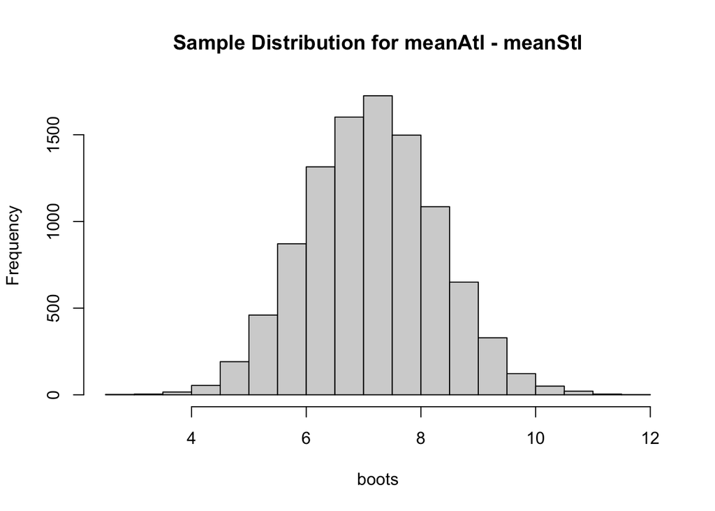

```r
set.seed(2016)
atl <- read.csv("https://www.lock5stat.com/datasets1e/CommuteAtlanta.csv")
stl <- read.csv("http://www.lock5stat.com/datasets1e/CommuteSt.Louis.csv")

atlTime <- atl$Time
stlTime <- stl$Time

boots <- NULL
for(i in 1:10000){
  meanAtl <- mean( sample(atlTime, 500, replace=TRUE))
  meanStl <- mean( sample(stlTime, 500, replace=TRUE))
  boots <- c(boots, meanAtl - meanStl)
}
hist(boots, main="Sample Distribution for meanAtl - meanStl")
```

```r
quantile(boots, c(.025,.975))
```

```
##    2.5%   97.5%
## 4.97200 9.40205
```

```r
(mean(atlTime) - mean(stlTime) ) + 2*c(-sd(boots), sd(boots))
```

```
## [1] 4.859005 9.420995
```

The two intervals are close. Usually we want the two intervals to be close and if they are not more advanced bootstrapping techniques maybe necessary.

In this case the two samples were both 500 while this is preferred this does not always have to be the case.

What is our interpretation of the confidence interval?

Lets say we want to compare the difference in the averages of SAT scores for men and women.

```r
survey <- read.csv("http://www.lock5stat.com/datasets1e/StudentSurvey.csv")
males <- subset(survey, Gender == "M")
females <- subset(survey, Gender == "F")

dim(males)
```

```
## [1] 193  17
```

```r
dim(females)
```

```
## [1] 169  17
```

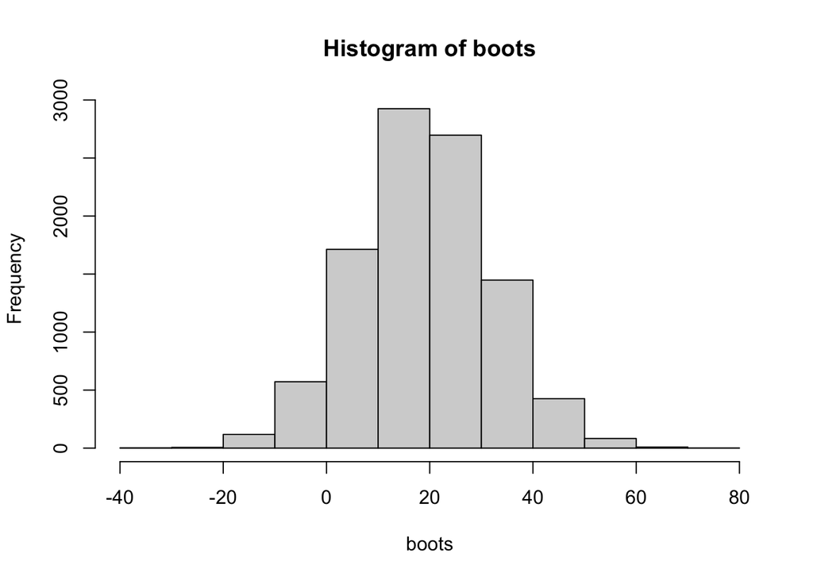

```r
boots <- NULL
for(i in 1:10000){
  maleAvg <- mean( sample(males$SAT, 193, replace=TRUE))
  femaleAvg <- mean(sample (females$SAT, 169, replace=TRUE))
  boots <- c(boots, maleAvg - femaleAvg)
}
hist(boots)
```

```r
quantile(boots, c(.025,.975))
```

```
##      2.5%     97.5%
## -6.383986 44.388681
```

```r
(mean(males$SAT) - mean(females$SAT) ) + 2*c(-sd(boots), sd(boots))
```

```
## [1] -6.842499 44.909826
```

Before you create a confidence interval using a bootstrap interval you need to check the bootstrap distribution. The bootstrap distribution needs to be reasonably centered around the original point estimate. Here is an example looking at the median of a sample of 25 Mustangs cars being sold online.

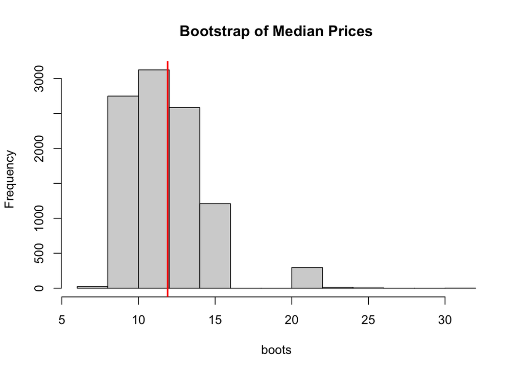

```r
dat <- read.csv("http://www.lock5stat.com/datasets1e/MustangPrice.csv")
prices <- dat$Price

boots <- NULL
for(i in 1:10000){
  stat <- median(sample(prices,25, replace=TRUE))
  boots <- c(boots, stat)
}
hist(boots, main="Bootstrap of Median Prices")
abline(v=median(prices), col="red", lwd=2)
```

You want your bootstrap distribution to be reasonably symmetric around your original estimate. Also we want our sampling distribution to be “filled out”. It should resemble the distribution of a continuous variable. For sample statistics like the median typically a “smooth” bootstrap is done. In a module later in this course, we will discuss other types of bootstrap methods that are computationally complex.

## Randomized Distributons

Randomized distributions are the hypothesis test version of bootstrapping. Again everything goes back to the creation of a sampling distribution, in this case we refer to it as a null distribution. The entire goal is to simulate the null distribution so that we can see how our data relates to that distribution.

## Hypotheses Testing

$$H_0: \mbox{Null Hypothesis: Claim that there is no effect or difference
(simple model, always has the equal sign, could be equal, greater than
equal or less than equal)} \\
H_A: \mbox{Alternative Hypothesis: Claim for which we seek evidence
(complex model)}$$

Lets look at a quick example, let’s say that a friend claims to be able to predict whether a stock will go up or down on a daily basis. We would evaluate that as they can pick better than 50% of the time. The idea is we’d want to say that the person predicts better than a random guess. So the hypotheses become
$$H_0: p \leq 1/2 \mbox{ Random chance} \\
H_A: p > 1/2 \mbox{ Better then random chance}$$

Two possible actions:

- We reject $H_0$ and accept $H_A$.
- Don’t have enough evidence to reject $H_0$. It is possible $H_0$ is true, or we have insufficient information (lack of data is one possible cause).

In statistics we can reject point estimates but we cannot prove they are true.\

The idea is that we want to be able to to determine based on the data we have whether the null hypothesis is plausible. To do this we use p-values.

*p-value:* Probability of obtaining a test statistic at least as extreme as the one observed assuming the null hypothesis is true. This is a critical definition for us

We compare the *p-value* to some significance level $\alpha$, if it is below that threshold it means that we believe that the probability is to small for our data to have been generate by the null distribution and we should reject the null hypothesis. If it’s larger than the threshold, we are saying that based on evidence we can’t conclude that the data was not generated by that null distribution. In my opinion one of the keys to good decision making with statistics is understanding what p-values actually mean and whether you can really draw the conclusion that you want to. It’s much more complicated than reject if below .05, or sometimes you’ll hear it as the star rule (which you’ll see in software output later in this course).

| Truth Outcomes | Reject $H_0$ | Fail to Reject $H_0$ |
| --- | --- | --- |
| $H_0$ True | Type I Error | Correct Decision |
| $H_0$ False | Correct Decision | Type II Error |

$$\begin{align*}
P\left(\mbox{Type I error } \mid H_0 \mbox{ True} \right) &=
$\alpha$ \\
P\left(\mbox{Type II error} \mid H_0 \mbox{ False} \right) &= \mbox{
Unknown but decreases as } n \mbox{ increases } \\
&= \mbox{ Unknown but decreases as true difference increases } \\
P\left(\mbox{Reject } H_0\right) &= \mbox{ Power of a Test} \\
H_0 \mbox{ true } \mbox{Power } &= P\left(\mbox{Type I Error}\right)
\\
H_0 \mbox{ false } \mbox{Power } &= 1-P\left(\mbox{Type II
Error}\right)
\end{align*}$$

Power also will increase with sample size.

Comparing Two Means Say we did an experiment comparing two marketing initiatives. We performed an experiment on 10 similar products where the strategy was randomly assigned 5 products used machine learning aided strategies and 5 used human recommended strategies. We got the following profit results in thousands of dollars.

| Human Aided | ML Aided |
| --- | --- |
| 113 | 135 |
| 150 | 130 |
| 117 | 126 |
| 139 | 121 |
| 107 | 147 |

If we look at the differences in sample means we have
$$\begin{align*}
\bar{x}_{\text{ML}} - \bar{x}_{\text{Human}} = 6.6.
\end{align*}$$

We are going to create a randomized distribution to see if this difference is statistically significant.

```r
human <- c(113,150,117,139,107)
ml <- c(135,130,126,121,147)
mktData <- data.frame(profit=c(human, ml),
        strategy = c(rep("Human",5),rep("ML",5)))
originalDif <- mean(ml) - mean(human)
```

Remember the basic idea is to randomly sample under the null distribution. So we need to figure out what the hypothesis is. It would make sense to claim that the machine learning aided methods will do better than the human aided. This would justify an investment in the technology so seems like the reasonable hypothesis.

So we define the hypothesis as the ml aided method is better, which is an alternative hypothesis, leaving the null to be that the human aided algorithm is as good or better than the ml algorithm.  
The null distribution is that the method doesn’t matter, so how do we deal with that, we randomly assign the methods to the results to see what that distribution would look like.

```r
newMkt <- sample(mktData$strategy, 10)
newData <- data.frame(profit=mktData$profit, strategy= newMkt)
newData
```

```
##    profit strategy
## 1     113       ML
## 2     150    Human
## 3     117       ML
## 4     139    Human
## 5     107    Human
## 6     135       ML
## 7     130       ML
## 8     126    Human
## 9     121       ML
## 10    147    Human
```

```r
tapply(newData$profit, newData$strategy, mean)
```

```
## Human    ML
## 133.8 123.2
```

```r
newMeans <- tapply(newData$profit, newData$strategy, mean)
newHumanMean <- newMeans[1]
newMlMean <- newMeans[2]
newMlMean - newHumanMean
```

```
##    ML
## -10.6
```

Lets now do 10,000 of these to get the sampling distribution

```r
set.seed(1000)
randomResults <- NULL
for(i in 1:10000){
newMkt <- sample(mktData$strategy, 10)
newData <- data.frame(profit=mktData$profit, strategy= newMkt)
  newMeans <- tapply(newData$profit, newData$strategy, mean)
  randomResults <- c(randomResults, newMeans[2] - newMeans[1])
}
```

Now we can look at a histogram of the results

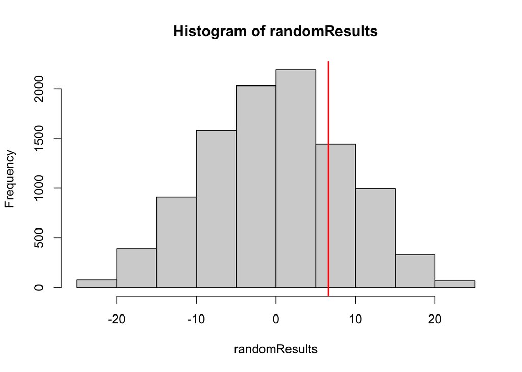

```r
hist(randomResults)
abline(v=originalDif, col="red", lwd=2)
```

The red mark here dictates where our data said the difference is.

The p-value is the probability of being above the red line, which can be calculated by doing.

```r
greaterThanOrig <- randomResults > originalDif
sum(greaterThanOrig) / 10000
```

```
## [1] 0.2342
```

If for some reason we wanted to preform a two sided test the p-value would be

```r
absGreaterThanOrig <- abs(randomResults) > abs(originalDif)
sum(absGreaterThanOrig) / 10000
```

```
## [1] 0.4651
```

### Correlation Example

Randomized distributions are a useful tool if our sample sizes are too small to trust asymptotic distribution (in other words use the Central Limit Theorem) or sometimes the central limit theorems require stronger assumptions. Sample correlation has a central limit theorem but its assumptions are stronger then the one for sample means.

We will look at the relationship between the malevolence of a team’s uniform and the number of penalty yards a team gets in a game. Let $s_x$ and $s_y$ be the sample standard deviation for x and y.

Sample correlation is calculated by:
$$\begin{align*}
r= \frac{1}{n-1} \sum_{i=1}^n \left(\frac{x_i -
\bar{x}}{s_x}\right)\left( \frac{(y_i - \bar{y})}{s_y}\right)
\end{align*}$$

Here we load the data and check the sample correlation

```r
nfl <- read.csv("http://www.lock5stat.com/datasets1e/MalevolentUniformsNFL.csv")[,c(1:3)]
sampleCor <- with(nfl, cor(ZPenYds, NFL_Malevolence))
```

Here is a plot of the data with a line fit to it.

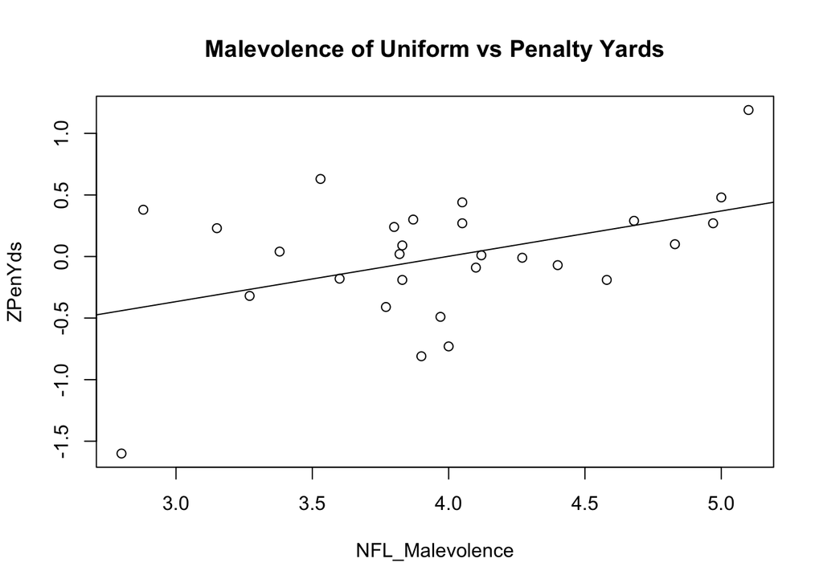

```r
m1 <- lm(ZPenYds ~ NFL_Malevolence, nfl)
#fitting the line you can ignore this for now we will discuss this later
with(nfl, plot(NFL_Malevolence, ZPenYds, main="Malevolence of Uniform vs Penalty Yards"))
abline(m1)
```

Our hypothesis is

$$\begin{align*}
H_0: \rho \leq 0 \\
H_1: \rho > 0
\end{align*}$$

When creating the randomized distribution we assume that $H_0$ is true. We will randomly assign the penalty yards to the teams and see what the range of values of possible correlations are if $H_0$ is true.

```r
set.seed(1863)
mixedYds <- sample(nfl$ZPenYds) #remix order of yards
newData <- nfl #give new data the original data
newData$ZPenYds <- mixedYds
#the replace original yards with new mixture
with(newData, cor(ZPenYds, NFL_Malevolence))
```

```
## [1] 0.1672568
```

New plot of data and line

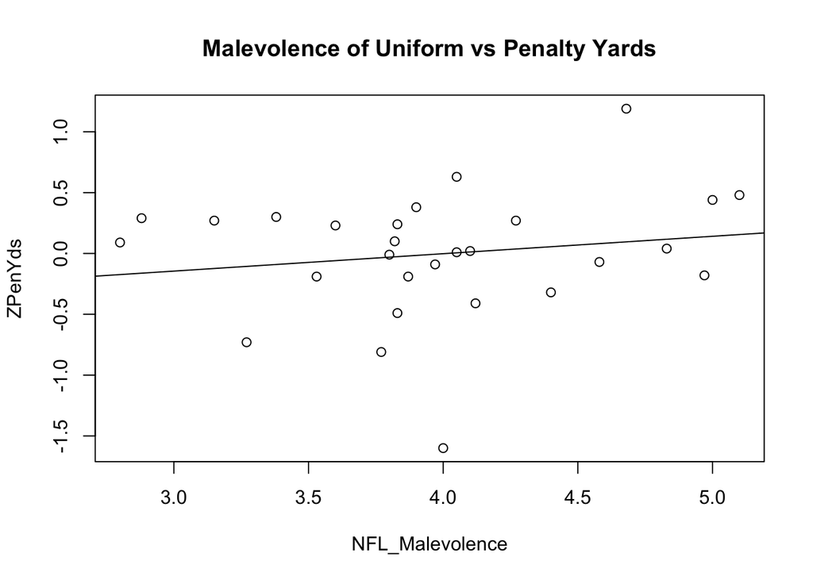

```r
m2 <- lm(ZPenYds ~ NFL_Malevolence, newData)
with(newData, plot(NFL_Malevolence, ZPenYds, main="Malevolence of Uniform vs Penalty Yards"))
abline(m2)
```

Now lets do it a whole bunch of times (10,000) to get our new randomized distributions.

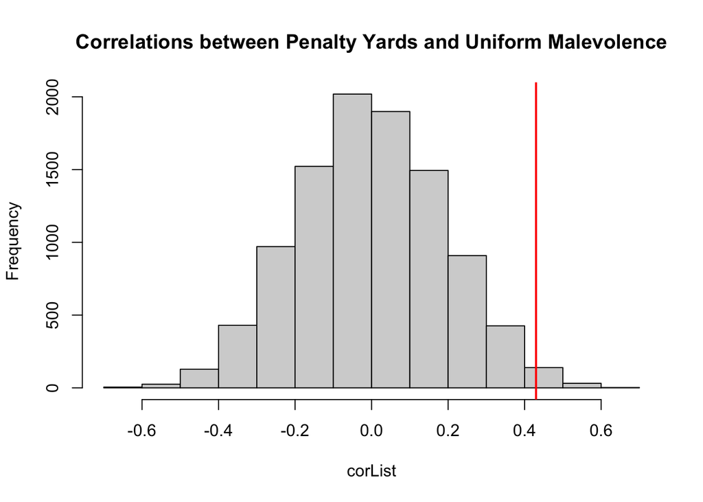

```r
set.seed(1863)
corList <- NULL
for(i in 1:10000){
  mixedYds <- sample(nfl$ZPenYds)
  corList <- c(corList, cor(nfl$NFL_Malevolence, mixedYds))
}

hist(corList, main="Correlations between Penalty Yards and Uniform Malevolence")
abline(v=sampleCor, col="red", lwd=2)
```

Lets do a one sided test

```r
greaterThen <- corList > sampleCor
sum(greaterThen) / 10000
```

```
## [1] 0.0109
```

P-value is very small and we can feel safe about rejecting $H_0$ and conclude there is a positive correlation between Malevolent uniforms and amount of yards penalized. Remember correlation is not causation though and this was not an experiment so there can be confounding variables explaining the true relationship.